# Stupidest sampler presentation

## 10000 random coins

function runif generates random numbers from a flat uniform distribution

```r
Hpr<-runif(10000,min=0,max=1)
l<-dbinom(3,4,Hpr) #likelihood that they produced the data
```

## 1000 random coins

from the original 10000

```r
samples<-sample(Hpr,1000,replace=T,prob=l)
str(samples)
```

```
##  num [1:1000] 0.774 0.674 0.488 0.596 0.211 ...
```

## The samples

is just a long row of parameter values that correspond to plausible hypotheses. That is, what a sampled posterior is.

## Histogram of samples

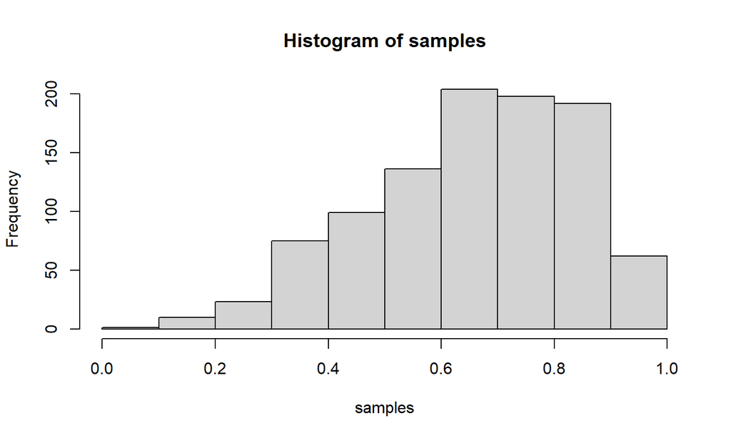

```r
hist(samples)
```

You can already see that it resembles the curve that we got from the analytical approach

#Density by KDE I need to multiply the original “post” variable, because now the discrete probabilities sum up to 1, not the area of the whole polygon such as is the default.

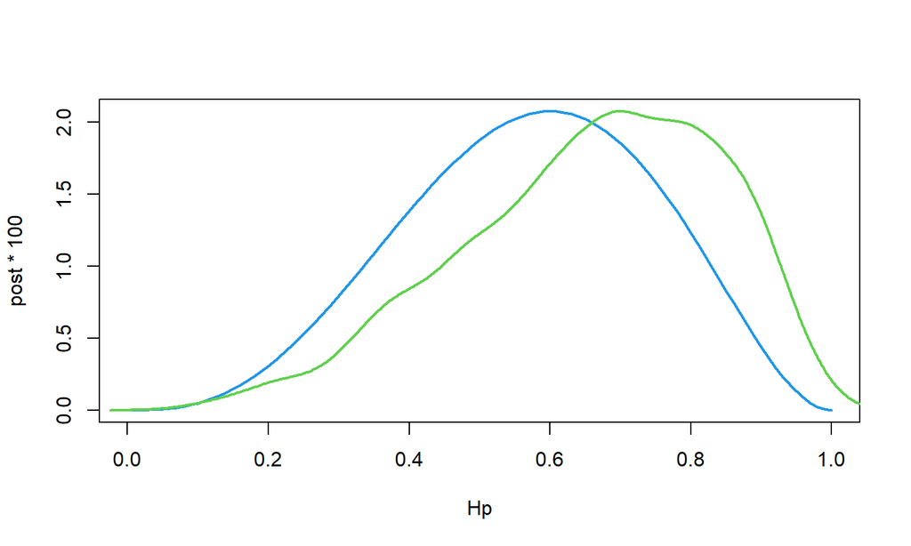

```r
dens<-density(samples)
plot(Hp,post*100,type="l",lwd=2,col=4)
lines(dens$x,dens$y,lwd=2,col=3)
```

## Before we disect The Stupidest Sampler Ever

let me introduce an example that really needs more than 1 parameter. And let me (re)introduce logarithms along the way.

## Power of logarithm

Logarithm is defined as a function inverse to exponential function

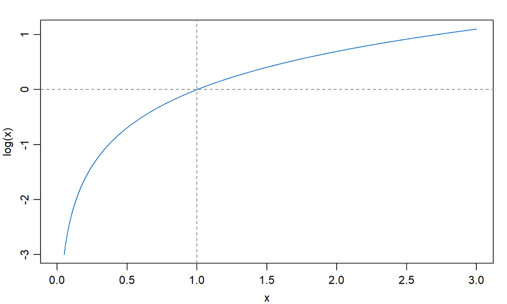

## Power of logarithm

Logarithm is defined as a function inverse to exponential function \[5=e^{\text{log}(5)}\] \[5=2^{\text{log}(5,\text{base}=2)}\]

```r
log(exp(5))
```

```
## [1] 5
```

```r
exp(log(3))
```

```
## [1] 3
```

## Power of logarithm

Invented to translate between multiplicative and additive processes \[5=e^{\text{log}(5)}\] \[5=2^{\text{log}(5,\text{base}=2)}\]

## Power of logarithm

Which is used in probability calculations on stupid discrete-states computers :) But also in data visualizations and handling. It is important to understand logarithms if you want to practice anything science-like.

## Power of logarithm

Logarithms transform clumsy multiplicative processes to easily handled additive process. Logarithms make big numbers (>1) smaller and small numbers (<1) negative.

When our ancestors needed to multiply 3 large numbers, They took their logarithms

```r
N<-c(225698,556877988,3546899)
(logN<-log(N))
```

```
## [1] 12.32695 20.13786 15.08158
```

## Power of logarithm

Added the logarithms together

```r
(sumN<-sum(logN))
```

```
## [1] 47.54639
```

And then raised e (natural logarithm base) to the resulting sum

```r
exp(sumN)
```

```
## [1] 4.457964e+20
```

## Now we have computers

```r
prod(N)
```

```
## [1] 4.457964e+20
```

But logarithms are still very useful

## Let me demonstrate:

First I will define a neater plotting function than the default one

```r
myplot<-function(x,y,y2=NULL,rounding=2,mycol="#2288FF",...){
  namx<-deparse(substitute(x))
  namy<-deparse(substitute(y))

  par(mar=c(4,4,4,1),mgp=c(2.2,1,0))
  plot(x,y,col=mycol,pch=16,xlab=namx,ylab=namy,...)
}
```

## Upload some data

```r
d<-read.table("gdppopdata.txt" ,sep="\t",header=T)
#There are some NAs for bigger units such as EU or OECD, that I discard
d<-d[!is.na(d$population),]
```

## See what we got here

On natural scales - GDP and population size, the data are messy, unbalanced, horribly heteroscedastic, possibly nonlinear

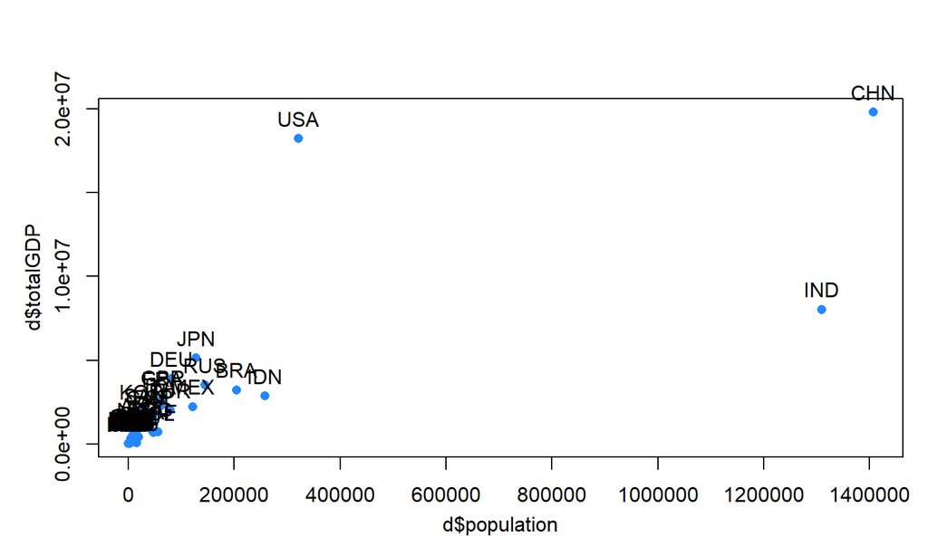

## See what we got here

But that is because the process generating population size and GDP is not additive

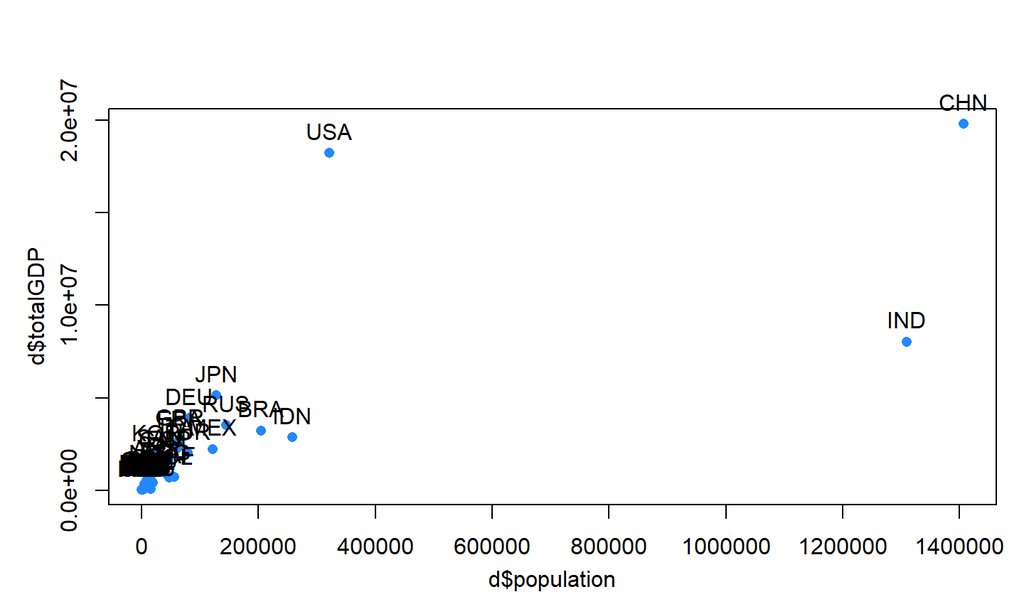

## See it loged

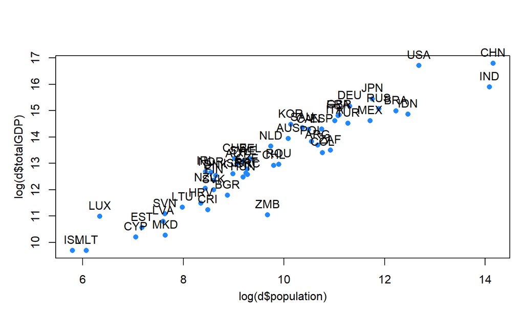

```r
myplot(log(d$population),log(d$totalGDP))
text(log(d$population),log(d$totalGDP),d$abr,pos=3,xpd=T)
```

## You can change the base

[figure not shown]

```r
?log
```

## GDP is in millions, population in thousands

Czech republic is the red point

```r
myplot(log(d$population*1000,10),log(d$totalGDP*1000000,10))
points(log(d$population*1000,10)[d$abr=="CZE"],log(d$totalGDP*1000000,10)[d$abr=="CZE"],col=2,pch=16)
abline(v=log(d$population*1000,10)[d$abr=="CZE"],col=2,lty=2)
abline(h=log(d$totalGDP*1000000,10)[d$abr=="CZE"],col=2,lty=2)
```

## GDP is in millions, population in thousands

Czech republic is the red point

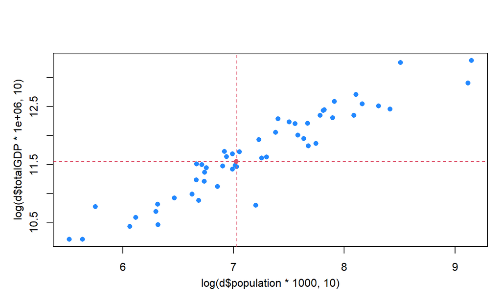

## How about base 1.1

```r
better<-d
better$population<-log(d$population*1000,1.1)
better$totalGDP<-log(d$totalGDP*1000000,1.1)
```

## If we plot it and find Czech republic on the graph

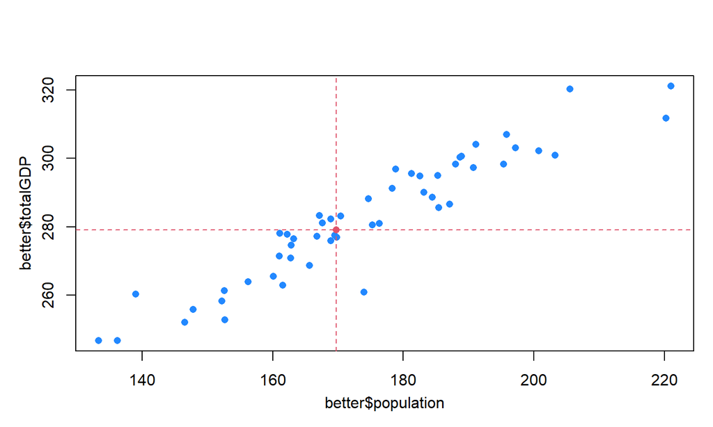

## We can easily talk about differences between countries on this scale

```r
cze<-better$totalGDP[better$abr=="CZE"]
usa<-better$totalGDP[better$abr=="USA"]
```

```
##      cze      usa
## 279.0495 320.3625
```

## difference between them

```r
(dif<-usa-cze)
```

```
## [1] 41.31292
```

The difference between Czechia and USA is 41. That means to get USA GDP, we would have to multiply our current GDP by 1.1 41 times (that means increase our GDP by 10% than increase the result by 10% again and so on and so on…)

```r
1.1*1.1
1.1*1.1*1.1
1.1^3
1.1^dif
```

[output not shown]

```
## [1] 51.29237
```

The difference between Czech and USA GDP is 51.29 which means that USA has 51times higher GDP than Czech republic. All it takes is 41 increases by 10%

## We can demonstrate that the numbers fit

```r
multip<-1.1^dif

d$totalGDP[d$abr=="CZE"]*multip
d$totalGDP[d$abr=="USA"]
```

```
## [1] 18224780
```

```
## [1] 18224780
```

## What to do?

Such large numbers are, again, not very good for our imagination. Can we easily try out conversions between different bases?

## Sure!

```r
log(1.1^dif,base=10)
```

```
## [1] 1.710053
```

Difference that is 41 on a scale of base 1.1 is not even two on the scale of base 10

```r
log(1.1^dif,base=2)
```

```
## [1] 5.680672
```

## So Let us go with that!

```r
best<-d
best$population<-log(d$population*1000,2)
best$totalGDP<-log(d$totalGDP*1000000,2)
```

## The plot

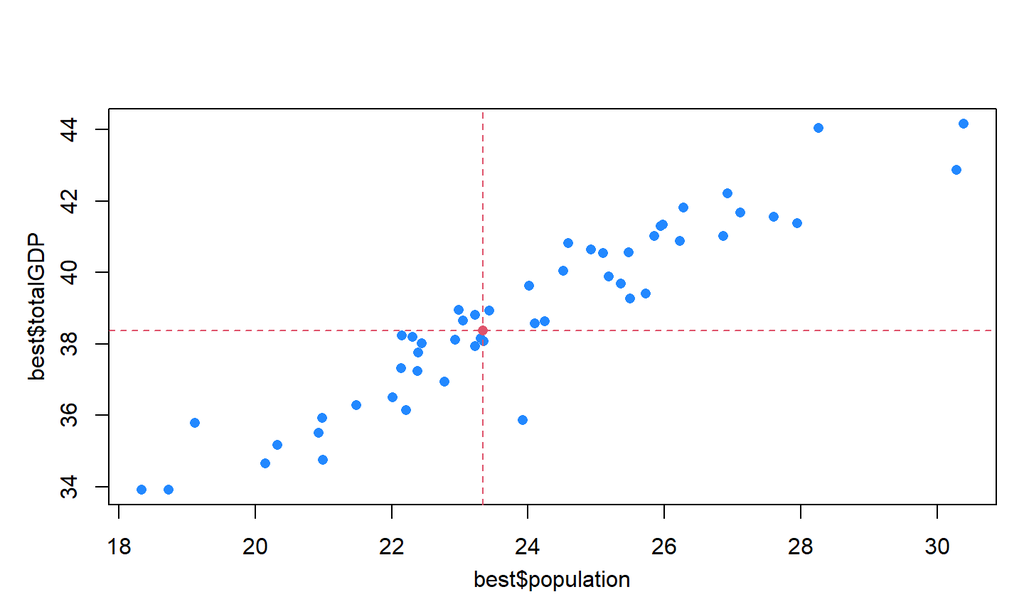

## Set a reference to 0

and report the units of multiplication towards this threshold.

```r
best$population<-best$population-best$population[best$abr=="CZE"]
best$totalGDP<-best$totalGDP-best$totalGDP[best$abr=="CZE"]
```

## Now Czech republic is at 0

and all other scores represent *2 (positive) or /2 (negative) changes in GDP or population size

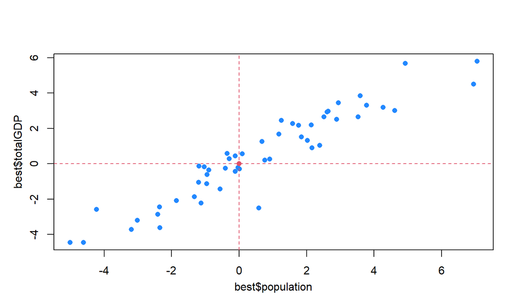

## So how to parametrize such a system into a set of plausible hypotheses?

Let us pretend now, that we did never see the data (that would be cheating), but we try to model some non-deterministic linear relationship. Obviously one of possible linear relationships is a a straight line - i.e. no relationship, independence of GDP on population.

## So how to parametrize such a system into a set of plausible hypotheses?

A thing that high school maths desperately lacks, in my opinion, is the introduction of non-deterministic equivalent of this symbol \(=\)

## So how to parametrize such a system into a set of plausible hypotheses?

It is called tilde and it looks like this \(\sim\) We do not read it “is equal to” but perhaps “is randomly drawn from a distribution”

## There is an empty plot that calls for data

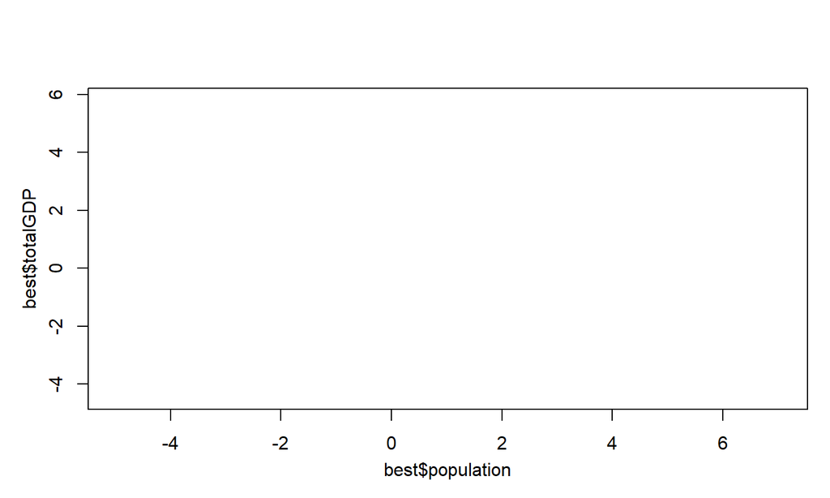

```r
myplot(best$population,best$totalGDP,type="n")
```

## How might such data arise?

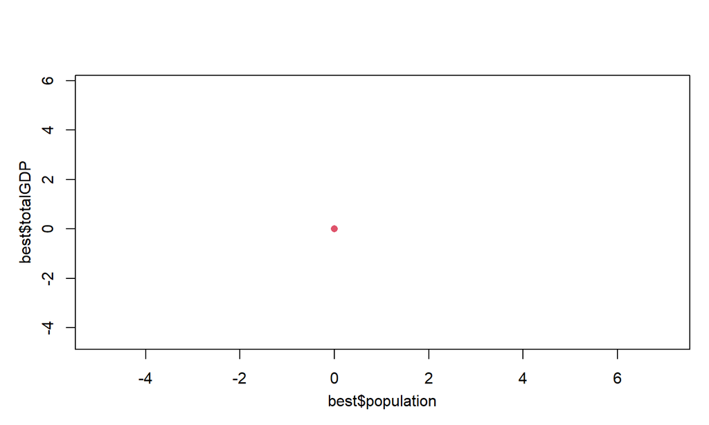

```r
myplot(best$population,best$totalGDP,type="n")
points(0,0,col=2,pch=16)
```

We know that Czechia is at point 0,0

## But should that country be there?

How much more value of the final goods and services should Czechia produce given the almost 11 million people that live here.

## But should that country be there?

We know that the number we have in our data is 0. But that is the data! that is not the predictive system that is not deterministic. We can say, that this 0 is drawn from a distribution around expected value \(a\).

## Let us assume

that this \(a\) (how much Czech GDP should be) is 1.

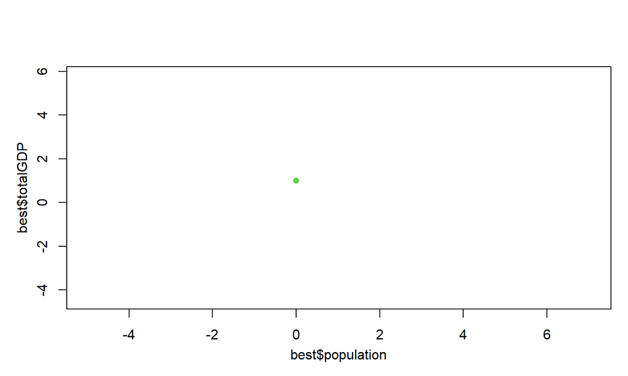

```r
myplot(best$population,best$totalGDP,type="n");points(0,1,col=3,pch=16)
```

1 on base-2 logarithmic scale means that Czech GDP should be twice as big than it is.

## We, of course, need to define a distribution.

The distribution will not be binomial as distribution of coin tosses, obviously. It will be a distribution that allows to draw any number, possibly positive as well as negative, around an expected mean \(a\), without a preference for higher or lower numbers.

## Choosing a distribution can seem like a challenge at a first sight

but really, it is not. We have a maximum entropy criteria. See here: https://en.wikipedia.org/wiki/Maximum_entropy_probability_distribution There is a super useful table!

## If you use maximum entropy distribution, you do not assume anything you do not actually want to assume.

## (See chapter 10 in Rethinking)

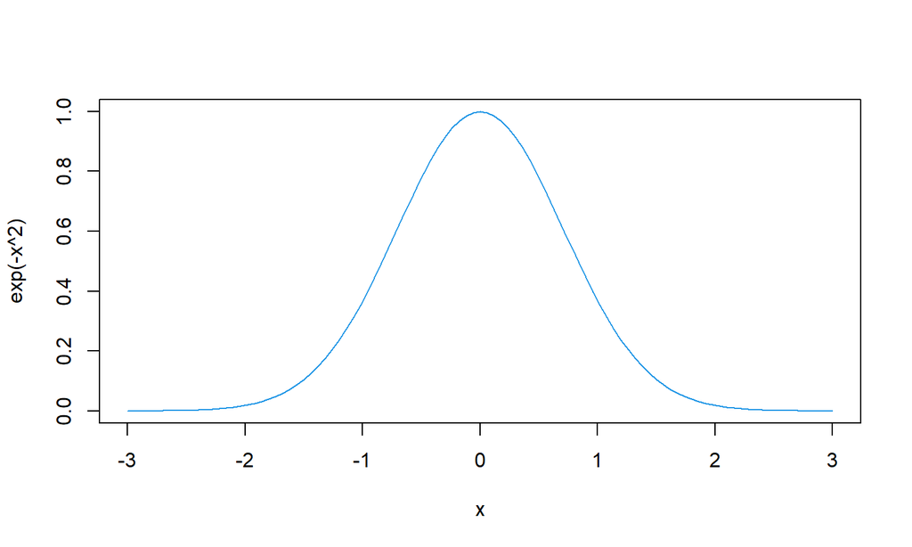

```r
curve(exp(-x^2),xlim=c(-3,3),col=4)
```

All you need to know about its shape is, that is basically \(e\) to the power of \(-x^2\). https://en.wikipedia.org/wiki/Normal_distribution

#So in such a system: GDP of czechia is drawn from a nromal distribution with mean \(a\) (for example \(a=1\)) and standard deviation \(sigma\) (for example \(sigma=0.5\))

```r
a<-1
sigma<-0.5
```

#So in such a system: GDP of czechia is drawn from a nromal distribution with mean \(a\) (for example \(a=1\)) and standard deviation \(sigma\) (for example \(sigma=0.5\))

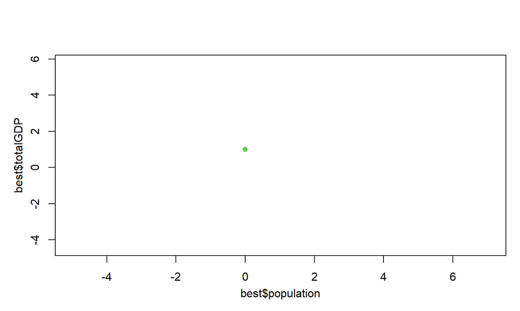

```r
myplot(best$population,best$totalGDP,type="n")
points(0,a,col=3,pch=16)
```

## Let us generate

50 possible Czechias from this distribution and put them into the plot.

```r
(newczech<-rnorm(50,mean=a,sd=sigma))
myplot(best$population,best$totalGDP,type="n")
points(0,a,col=3,pch=16)
points(rep(0,50),newczech,col="#88888820",pch=16)
points(0,0,col=2,pch=16)
```

## Let us generate

50 possible Czechias from this distribution and put them into the plot.

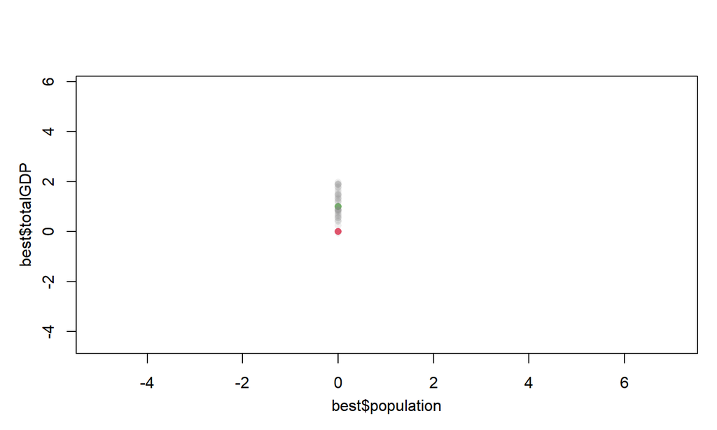

## Let us calculate

The red dot - the GDP=0 in the data is at the very edge of the generated values, but if we check the value of probability density function, we see, that it is indeed quite possible to draw it from such a distribution.

```r
dnorm(0,mean=a,sd=sigma)
```

```
## [1] 0.1079819
```

## Let us calculate

It is obviously much more likely to draw numbers close to the mean.

```r
dnorm(1,mean=a,sd=sigma)
```

```
## [1] 0.7978846
```

## Add one more parameter.

We already have the expected value for Czechia, now we only need a GDP change with doubling the population.

\(b=-1\) it is.

```r
b<- -1
```

## So now there are expected value per log population size

```r
myplot(best$population,best$totalGDP,type="n")
points(0,a,col=3,pch=16)
points(rep(0,50),newczech,col="#88888820",pch=16)
points(0,0,col=2,pch=16)
abline(a=a,b=b,col=3)
```

## So now there are expected value per log population size

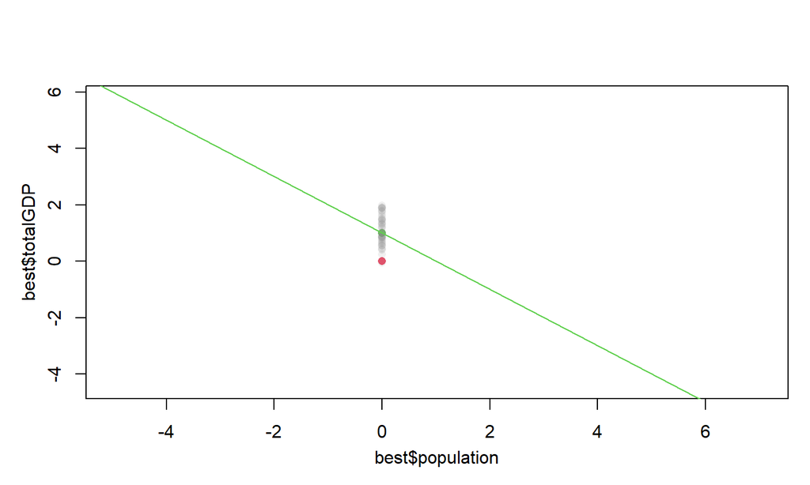

## So now there are expected value per log population size

And around it I can generate some random data: 100 new countries

```r
n<-100
rpop<-runif(n,-4,6)
```

We have their random populations uniformly distributed between -4 and 6

## We calculate the expected GDP for each country

with the simple linear equation And generate random deviation around each expected number

```r
mu<-a+b*rpop
rGDP<-rnorm(n,mu,sigma)
```

## Czechia blends quite well in

```r
myplot(best$population,best$totalGDP,type="n")
points(0,a,col=3,pch=16)
points(rep(0,50),newczech,col="#88888820",pch=16)
points(0,0,col=2,pch=16)
points(rpop,rGDP,col="#888888",pch=16)
```

## Czechia blends quite well in

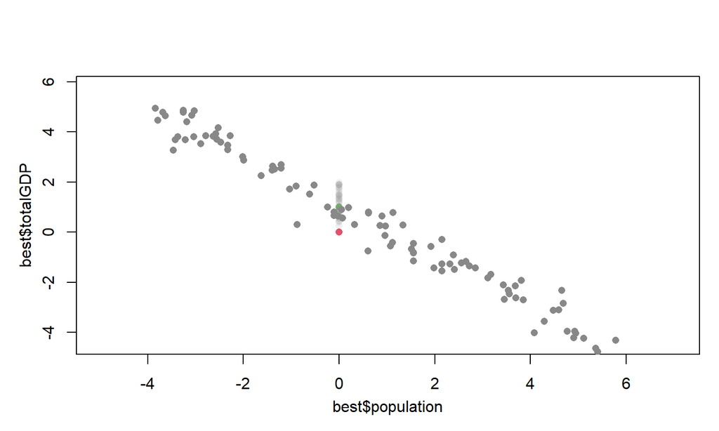

## So this is one of my possible hypotheses:

\(a=1\), \(b=-1\), \(\sigma=0.5\), my system has three parameters, so each hypothesis that i formulate within the system has these three parameters.

## It is obvious that it is not a very good system.

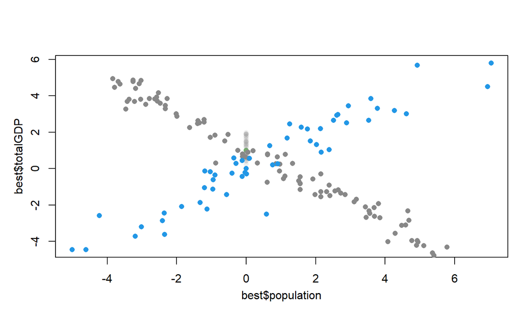

## Let us use our **STUPIDEST SAMPLER EVER** to get the distribution of likely triplets of parameter values

## When I generate random hypotheses

I need to specify random distribution from which I am even willing to draw the hypotheses (similarly as I did above with the single coin parameter p).

I will use maximum entropy criteria to pick these distributions - my initial “priors”.

I use relatively wide and unbiased initial priors.

## Random hypothesis generation

This is how many random hypotheses I generate

```r
nH<-100000
a<-rnorm(nH,mean=0,sd=1) #prior for a
b<-rnorm(nH,mean=0,sd=1) #prior for b
sigma<-rexp(nH,rate=1)   #exponential prior for sigma

hypotheses<-data.frame(a,b,sigma)
```

## Calculate data likelihood

for the first hypothesis

```r
i<-1
h<-hypotheses[i,]
per.point<-dnorm(best$totalGDP,h$a+h$b*best$population,h$sigma) #likelihood per point
prod(per.point)
```

```
## [1] 3.861136e-81
```

## The data likelihood

for this hypothesis is extremely low

```r
h
```

```
##            a         b     sigma
## 1 -0.4451603 0.7665312 0.3674329
```

## Maybe i will be more lucky elsewhere.

I will turn the likelihood into a function:

```r
mylikeli<-function(i){
  h<-hypotheses[i,]
  per.point<-dnorm(best$totalGDP,h$a+h$b*best$population,h$sigma) #likelihood per point
  return(prod(per.point))
}
```

## Calculate

\[P(d|H)\] for each random hypothesis

```r
hypotheses$data.l<-sapply(1:nrow(hypotheses),mylikeli)
```

## There are some

that allow for the generation of data as they are

```r
str(sort(hypotheses$data.l,decreasing=T))
```

```
##  num [1:100000] 4.98e-29 4.34e-29 3.72e-29 3.59e-29 3.49e-29 ...
```

## Second raffle

So let us draw again some of them, the probability that a hypothesis is drawn is proportional to the data likelihood

```r
sampled.h<-sample(1:nH,1000,replace=T,prob=hypotheses$data.l)
samples<-hypotheses[sampled.h,]
head(samples)
```

```
##                  a         b     sigma       data.l
## 66675 -0.030654863 0.9055258 0.8076245 3.586769e-29
## 6117  -0.082875096 0.8635820 0.7148599 1.181163e-29
## 10382 -0.022260724 0.9098604 0.7497132 1.767306e-29
## 4653  -0.161567931 0.9226635 1.0352707 3.878555e-30
## 64901  0.002761625 0.8337606 0.8092867 1.851608e-29
## 20879 -0.072502994 0.8863801 0.9451214 2.111593e-29
```

## I have a set of plausible hypotheses.

This is the first of them

```r
myplot(best$population,best$totalGDP)
points(0,0,col=2,pch=16)
abline(a=samples[1,]$a,b=samples[1,]$b)
abline(a=samples[1,]$a+samples[1,]$sigma*2,b=samples[1,]$b,lty=2)
abline(a=samples[1,]$a-samples[1,]$sigma*2,b=samples[1,]$b,lty=2)
```

## I have a set of plausible hypotheses.

This is the first of them

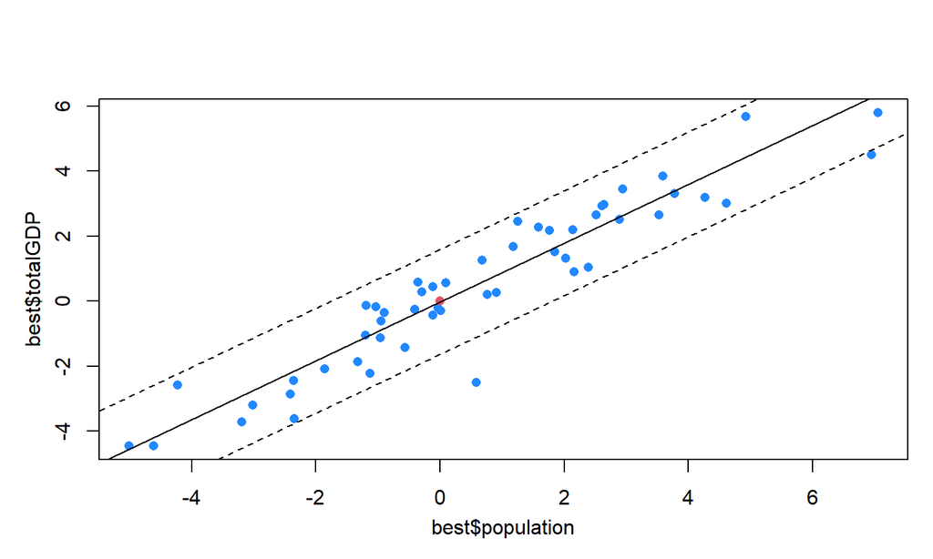

## 2 SDs on each side?

(You can calculate the density between n sigmas with cumulative distribution function)

```r
pnorm(2)-pnorm(-2)
```

```
## [1] 0.9544997
```

## This is second hypothesis

```r
myplot(best$population,best$totalGDP)
points(0,0,col=2,pch=16)
abline(a=samples[2,]$a,b=samples[2,]$b)
abline(a=samples[2,]$a+samples[2,]$sigma*2,b=samples[2,]$b,lty=2)
abline(a=samples[2,]$a-samples[2,]$sigma*2,b=samples[2,]$b,lty=2)
```

## This is second hypothesis

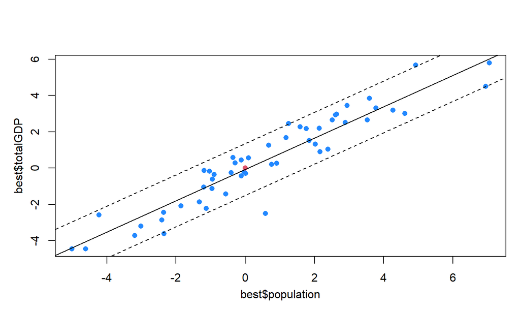

## 50 likely hypotheses

(but without the sigma parameter for clarity)

```r
myplot(best$population,best$totalGDP)
points(0,0,col=2,pch=16)
for(i in 1:50){
  abline(a=samples[i,]$a,b=samples[i,]$b,col="#80808080")
}
```

## 50 likely hypotheses

(but without the sigma parameter for clarity)

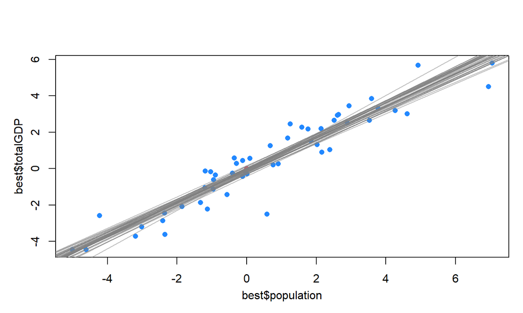

## Hypotheses more or less agree on some corridor.

Better visual than a bunch of rods

```r
x<-seq(-7,7,0.01)
y<-sapply(1:nrow(samples),function(i){samples[i,]$a+samples[i,]$b*x})
str(y)
```

```
##  num [1:1401, 1:1000] -6.37 -6.36 -6.35 -6.34 -6.33 ...
```

```r
muy<-apply(y,1,mean)
CIy<-apply(y,1,PI,prob=0.95)
```

This CI stands for compatibility interval

## Hypotheses more or less agree on some corridor.

Better visual than a bunch of rods

```r
myplot(best$population,best$totalGDP)
points(0,0,col=2,pch=16)
lines(x,muy)
shade(CIy,x)
```

## Hypotheses more or less agree on some corridor.

Better visual than a bunch of rods

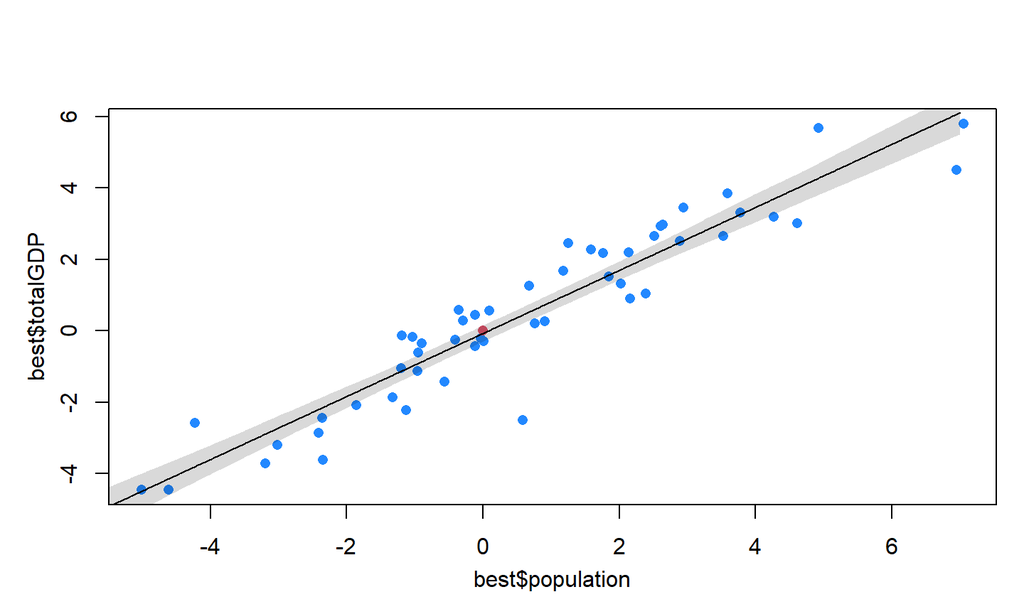

## There is an alternative to PI

**HPDI: Highest Posterior Density Interval**

```r
HPDIy<-apply(y,1,HPDI,prob=0.95)
myplot(best$population,best$totalGDP)
points(0,0,col=2,pch=16)
lines(x,muy)
shade(HPDIy,x)
```

## There is an alternative to PI: HPDI

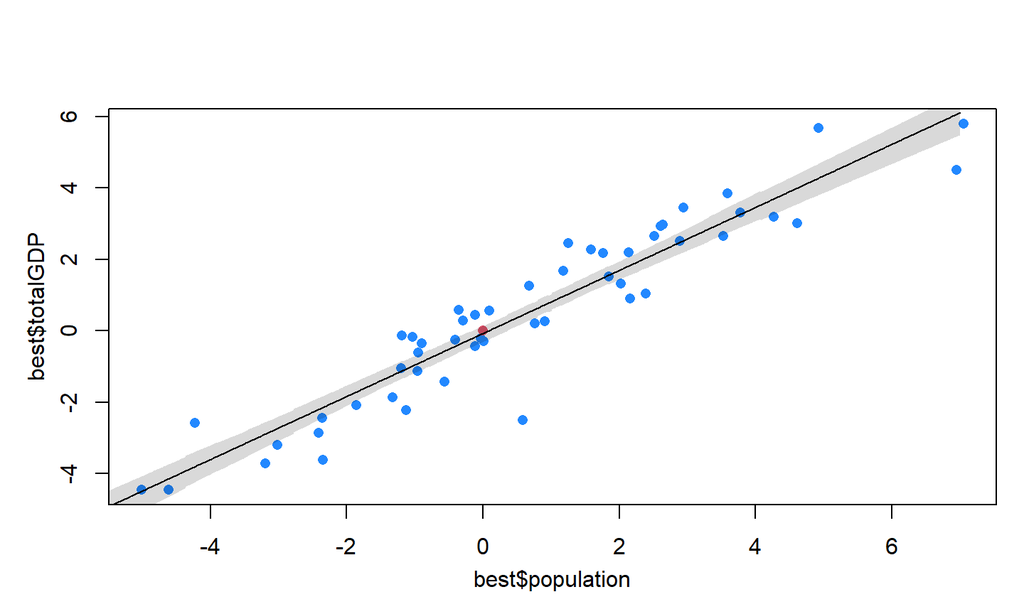

very frequently these two methods give almost identical results.

## Summarize the hypotheses by parameter

(you might find this under the name of “marginal projections of joint posterior distribution” more abut this to come).

```r
summary(samples$a)
```

```
##       Min.    1st Qu.     Median       Mean    3rd Qu.       Max.
## -0.4171069 -0.1644532 -0.0560953 -0.0786330  0.0004588  0.3889515
```

```r
PI(samples$a,prob=0.95)
```

```
##         3%        98%
## -0.3087431  0.1414994
```

With probability 95% a (difference between expected GDP of Czechia and the realized total GDPis close to 0).

If we use the PI function (first function from the rethinking package that we use), it does not give 95% but 89% CI by default.

## Parameter b

```r
mu.b<-summary(samples$b)
CI.b<-PI(samples$b,prob=0.95)
```

```
##    Min. 1st Qu.  Median    Mean 3rd Qu.    Max.
##  0.7365  0.8569  0.8864  0.8832  0.9118  1.0540
```

```
##        3%       98%
## 0.7987868 0.9670350
```

## Per doubling the population

(move one step right along the x axis), the GDP is expected to grow by factor of approx

```r
2^mu.b["Mean"]
```

```
##     Mean
## 1.844484
```

95% CI of this estimate is

```r
2^CI.b
```

```
##       3%      98%
## 1.739638 1.954819
```